# Genetic and epigenetic fine mapping of causal autoimmune disease variants

Mikhail Dozmorov

November 1, 2014

[Genetic and epigenetic fine mapping of causal autoimmune disease variants](http://www.nature.com/nature/journal/vaop/ncurrent/pdf/nature13835.pdf)

[Supplemental table 1](http://www.nature.com/nature/journal/vaop/ncurrent/extref/nature13835-s1.xls) has genomic coordinates of disease-associated SNPs.

# Analysis of TFBSs

Out of all regulatory datasets, we select only TFBSs.

```
## [1] 1954   39
```

```
## [1] 1259   38
```

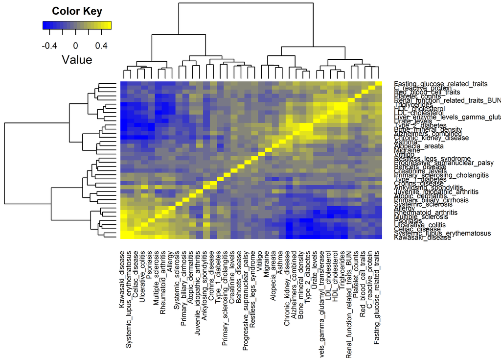

**Text mining question 1:** Are the diseases within a cluster share stronger literature similarity than the diseases between the clusters? To answer, we need literature similarity scores for each pair, then split the pairs into cluster-specific groups and compare score distributions with what can be expected by chance, calculating the p-values for it. *Expected answer:* Diseases within each cluster are related to each other by literature findings stronger than could be expected by chance. Diseases between the clusters are not related to each other by literature findings, and this also may be statistically significant.

The top 10 pairs of disease-associated SNPs are most similar with each other.

| Disease 1 | Disease 2 | Corr. coefficient |
| --- | --- | --- |
| HDL_cholesterol | Triglycerides | 0.5484 |
| Kawasaki_disease | Systemic_lupus_erythematosus | 0.5352 |
| Bone_mineral_density | Type_2_diabetes | 0.5268 |
| Kawasaki_disease | Multiple_sclerosis | 0.501 |
| Kawasaki_disease | Rheumatoid_arthritis | 0.4775 |
| Celiac_disease | Kawasaki_disease | 0.4754 |
| LDL_cholesterol | Triglycerides | 0.4743 |
| Kawasaki_disease | Ulcerative_colitis | 0.4661 |
| Liver_enzyme_levels_gamma_glutamyl_transferase | Urate_levels | 0.4191 |
| Alzheimers_combined | Bone_mineral_density | 0.4149 |

The similarity dendrogram can be divided into separate groups:

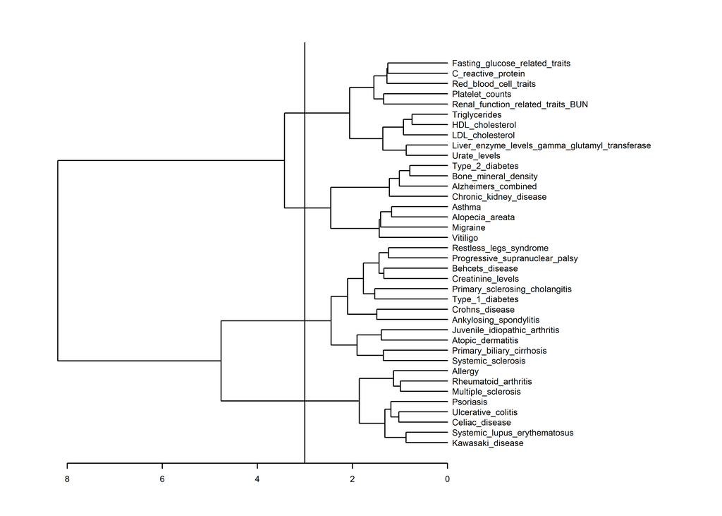

```
## Cluster01 has   8 members
## Kawasaki_disease
## Systemic_lupus_erythematosus
## Celiac_disease
## Ulcerative_colitis
## Psoriasis
## Multiple_sclerosis
## Rheumatoid_arthritis
## Allergy
##
## Cluster02 has  12 members
## Systemic_sclerosis
## Primary_biliary_cirrhosis
## Atopic_dermatitis
## Juvenile_idiopathic_arthritis
## Ankylosing_spondylitis
## Crohns_disease
## Type_1_diabetes
## Primary_sclerosing_cholangitis
## Creatinine_levels
## Behcets_disease
## Progressive_supranuclear_palsy
## Restless_legs_syndrome
##
## Cluster03 has   8 members
## Vitiligo
## Migraine
## Alopecia_areata
## Asthma
## Chronic_kidney_disease
## Alzheimers_combined
## Bone_mineral_density
## Type_2_diabetes
##
## Cluster04 has  10 members
## Urate_levels
## Liver_enzyme_levels_gamma_glutamyl_transferase
## LDL_cholesterol
## HDL_cholesterol
## Triglycerides
## Renal_function_related_traits_BUN
## Platelet_counts
## Red_blood_cell_traits
## C_reactive_protein
## Fasting_glucose_related_traits
##
```

```
## [1] "c1 vs. c2 , number of degs significant at adj.p.val<0.5 and 2-fold diff: 86"
## [1] "c1 vs. c3 , number of degs significant at adj.p.val<0.5 and 2-fold diff: 110"
## [1] "c1 vs. c4 , number of degs significant at adj.p.val<0.5 and 2-fold diff: 103"
## [1] "c2 vs. c3 , number of degs significant at adj.p.val<0.5 and 2-fold diff: 0"
## [1] "c2 vs. c4 , number of degs significant at adj.p.val<0.5 and 2-fold diff: 0"
## [1] "c3 vs. c4 , number of degs significant at adj.p.val<0.5 and 2-fold diff: 0"
```

**Text mining question 2:** Are the terms associated stronger with the diseases in one vs. the other cluster based on the literature strength? Are the terms themselves related based on the literature? *Expected answer:* Yes, the literature associations should confirm the relationships.

## Summary

1. There are 4 clusters. The first cluster drives all the differences.

|  | C1 | C2 | C3 | C4 |
| --- | --- | --- | --- | --- |
| C1 |  | Cell types: Gm12878 Reg: NFkB, Pol2, MTA3, NFIC, NFATC1 | Cell types: Gm12878 Reg: NFkB, Pol2, MTA3, NFIC, NFATC1 | Cell types: Gm12878 Reg: NFkB, Pol2, MTA3, NFIC, NFATC1 |
| C2 |  |  | Nothing significant | Nothing significant |
| C3 |  |  |  | Nothing significant |
| C4 |  |  |  |  |

# Analysis of histone marks

Out of all regulatory datasets, we select only histone marks

```
## [1] 721  39
```

```
## [1] 610  39
```

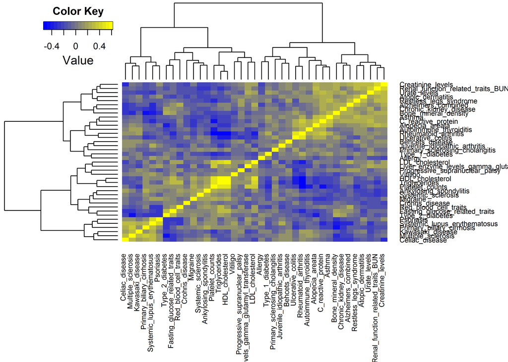

**Text mining question 1:** Are the diseases within a cluster share stronger literature similarity than the diseases between the clusters? To answer, we need literature similarity scores for each pair, then split the pairs into cluster-specific groups and compare score distributions with what can be expected by chance, calculating the p-values for it. *Expected answer:* Diseases within each cluster are related to each other by literature findings stronger than could be expected by chance. Diseases between the clusters are not related to each other by literature findings, and this also may be statistically significant.

The top 10 pairs of autoimmune-associated SNPs are most similar with each other.

| Disease 1 | Disease 2 | Corr. coefficient |
| --- | --- | --- |
| HDL_cholesterol | Triglycerides | 0.621 |
| Rheumatoid_arthritis | Ulcerative_colitis | 0.4856 |
| HDL_cholesterol | LDL_cholesterol | 0.48 |
| HDL_cholesterol | Platelet_counts | 0.4609 |
| Platelet_counts | Triglycerides | 0.4504 |
| LDL_cholesterol | Triglycerides | 0.4151 |
| Creatinine_levels | Renal_function_related_traits_BUN | 0.3915 |
| Psoriasis | Systemic_lupus_erythematosus | 0.3911 |
| Renal_function_related_traits_BUN | Urate_levels | 0.3689 |
| Alopecia_areata | C_reactive_protein | 0.3686 |

The similarity dendrogram can be divided into separate groups:

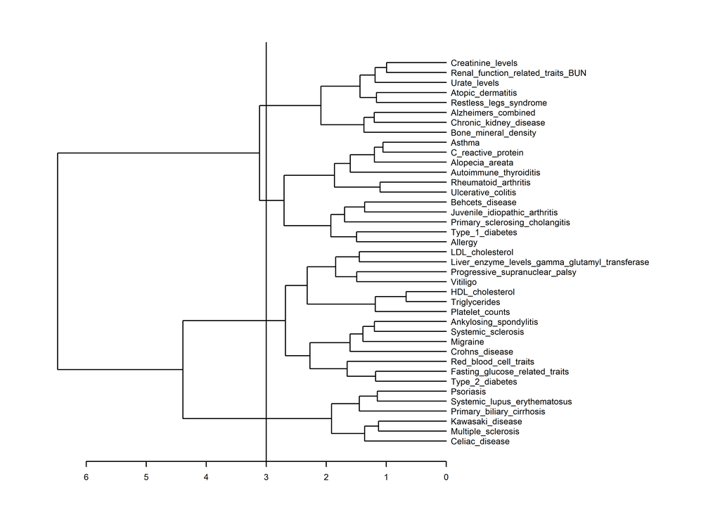

```
## Cluster01 has   6 members
## Celiac_disease
## Multiple_sclerosis
## Kawasaki_disease
## Primary_biliary_cirrhosis
## Systemic_lupus_erythematosus
## Psoriasis
##
## Cluster02 has  14 members
## Type_2_diabetes
## Fasting_glucose_related_traits
## Red_blood_cell_traits
## Crohns_disease
## Migraine
## Systemic_sclerosis
## Ankylosing_spondylitis
## Platelet_counts
## Triglycerides
## HDL_cholesterol
## Vitiligo
## Progressive_supranuclear_palsy
## Liver_enzyme_levels_gamma_glutamyl_transferase
## LDL_cholesterol
##
## Cluster03 has  11 members
## Allergy
## Type_1_diabetes
## Primary_sclerosing_cholangitis
## Juvenile_idiopathic_arthritis
## Behcets_disease
## Ulcerative_colitis
## Rheumatoid_arthritis
## Autoimmune_thyroiditis
## Alopecia_areata
## C_reactive_protein
## Asthma
##
## Cluster04 has   8 members
## Bone_mineral_density
## Chronic_kidney_disease
## Alzheimers_combined
## Restless_legs_syndrome
## Atopic_dermatitis
## Urate_levels
## Renal_function_related_traits_BUN
## Creatinine_levels
##
```

```
## [1] "c1 vs. c2 , number of degs significant at adj.p.val<0.5 and 2-fold diff: 45"
## [1] "c1 vs. c3 , number of degs significant at adj.p.val<0.5 and 2-fold diff: 47"
## [1] "c1 vs. c4 , number of degs significant at adj.p.val<0.5 and 2-fold diff: 58"
## [1] "c2 vs. c3 , number of degs significant at adj.p.val<0.5 and 2-fold diff: 32"
## [1] "c2 vs. c4 , number of degs significant at adj.p.val<0.5 and 2-fold diff: 9"
## [1] "c3 vs. c4 , number of degs significant at adj.p.val<0.5 and 2-fold diff: 0"
```

**Text mining question 2:** Are the terms associated stronger with the diseases in one vs. the other cluster based on the literature strength? Are the terms themselves related based on the literature? *Expected answer:* Yes, the literature associations should confirm the relationships.

## Summary

|  | C1 | C2 | C3 | C4 |
| --- | --- | --- | --- | --- |
| C1 |  | Cell types: Gm12878, CD20+ Reg: H3K4me1, H3K9me3, H3K9ac, H3K27ac, H2az, H3K4me2 | Cell types: Gm12878, CD20+ Reg: H3K4me1, H3K9me3, H3K9ac, H3K27ac, H2az, H3K4me2 | Cell types: Gm12878, CD20+ Reg: H3K4me1, H3K9me3, H3K9ac, H3K27ac, H2az, H3K4me2 |
| C2 |  |  | Cell types: K562, NHEK, NHDF-Ad, NH-A, HMEC Reg: H3K36me3, H4K20me1, H3K79me2 | Nothing significant |
| C3 |  |  |  | Nothing significant |
| C4 |  |  |  |  |

# Analysis of all regulatory datasets

Out of all regulatory datasets, we select all. The goal here is to get potentially tighter clustering.

```
## [1] 4498   39
```

```
## [1] 2969   39
```

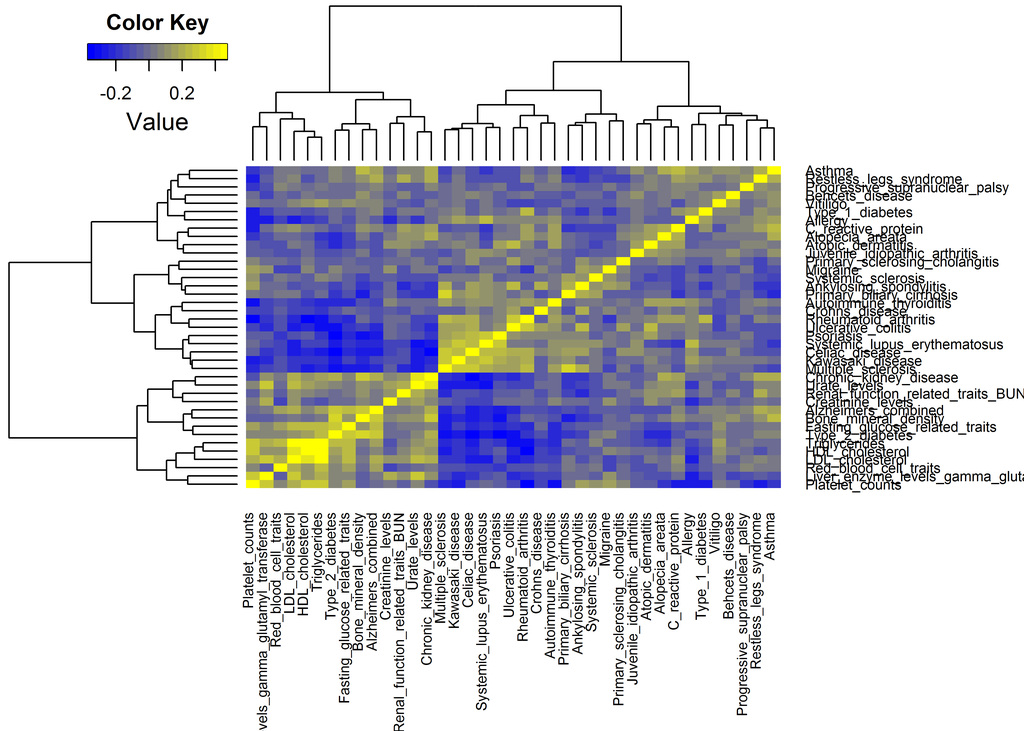

The top 10 pairs of disease-associated SNPs are most similar with each other.

| Disease 1 | Disease 2 | Corr. coefficient |
| --- | --- | --- |
| HDL_cholesterol | Triglycerides | 0.473 |
| LDL_cholesterol | Triglycerides | 0.4314 |
| Chronic_kidney_disease | Urate_levels | 0.3742 |
| HDL_cholesterol | LDL_cholesterol | 0.3475 |
| Bone_mineral_density | Type_2_diabetes | 0.3225 |
| Multiple_sclerosis | Primary_biliary_cirrhosis | 0.316 |
| Alzheimers_combined | Type_2_diabetes | 0.2999 |
| Liver_enzyme_levels_gamma_glutamyl_transferase | Urate_levels | 0.2976 |
| Fasting_glucose_related_traits | Type_2_diabetes | 0.2972 |
| Liver_enzyme_levels_gamma_glutamyl_transferase | Platelet_counts | 0.2944 |

The similarity dendrogram can be divided into separate groups:

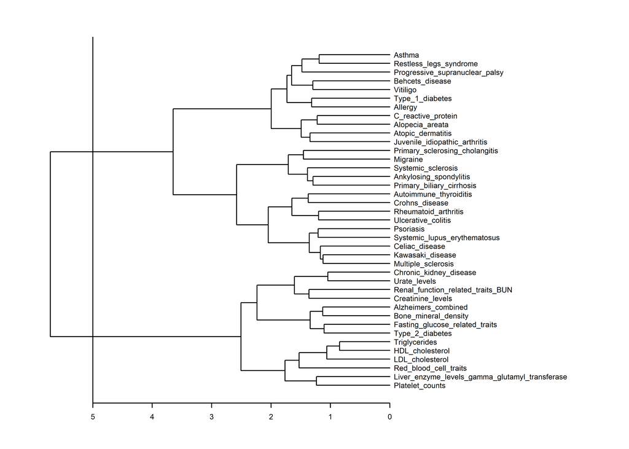

```
## Cluster01 has  14 members
## Platelet_counts
## Liver_enzyme_levels_gamma_glutamyl_transferase
## Red_blood_cell_traits
## LDL_cholesterol
## HDL_cholesterol
## Triglycerides
## Type_2_diabetes
## Fasting_glucose_related_traits
## Bone_mineral_density
## Alzheimers_combined
## Creatinine_levels
## Renal_function_related_traits_BUN
## Urate_levels
## Chronic_kidney_disease
##
## Cluster02 has  25 members
## Multiple_sclerosis
## Kawasaki_disease
## Celiac_disease
## Systemic_lupus_erythematosus
## Psoriasis
## Ulcerative_colitis
## Rheumatoid_arthritis
## Crohns_disease
## Autoimmune_thyroiditis
## Primary_biliary_cirrhosis
## Ankylosing_spondylitis
## Systemic_sclerosis
## Migraine
## Primary_sclerosing_cholangitis
## Juvenile_idiopathic_arthritis
## Atopic_dermatitis
## Alopecia_areata
## C_reactive_protein
## Allergy
## Type_1_diabetes
## Vitiligo
## Behcets_disease
## Progressive_supranuclear_palsy
## Restless_legs_syndrome
## Asthma
##
```

```
## [1] "c1 vs. c2 , number of degs significant at adj.p.val<0.5 and 2-fold diff: 0"
```

## Summary

The picture is not as good as when we are taking subsets of regulatory datasets.